# Reproducible Research Project 1

HDooster

Thursday, August 07, 2014

## Loading and preprocessing the data and making sure the dates are in class ‘Date’, not in class ‘Factor’.

```r
activity <- read.csv("activity.csv",header=T, sep=",", quote="\"",stringsAsFactors = FALSE)

activity$date <- as.Date(activity$date)
```

## What is mean total number of steps taken per day?

```r
#summing up the steps per day using aggregate
perday <- aggregate(formula = steps~date, data=activity, FUN=sum, na.action=na.omit)

#calculating mean and median
mean_perday <- mean(perday$steps)
median_perday <- median(perday$steps)

print(mean_perday)
```

```
## [1] 10766
```

```r
print(median_perday)
```

```
## [1] 10765
```

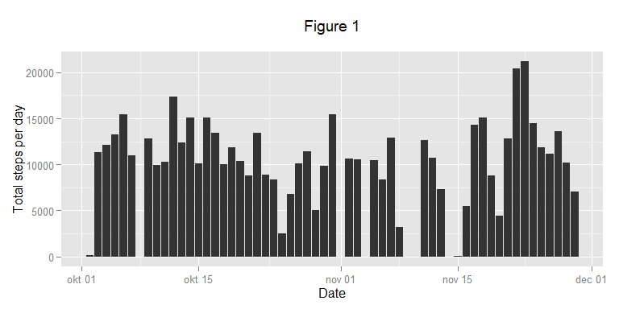

```r
require(ggplot2)
#plotting a histogram in ggplot
histogram <-  qplot(perday$date, perday$steps, stat='summary', fun.y=sum, geom='histogram') +
  labs(title='Figure 1\n',
       y='Total steps per day', x='Date')

plot(histogram)
```

## What is the average daily activity pattern?

```r
perinterval <- aggregate(formula = steps~interval, data=activity, FUN=mean, na.action=na.omit)
```

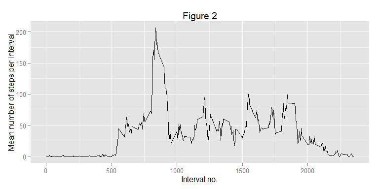

```r
plot2 <- qplot(perinterval$interval, perinterval$steps,geom='line') +
labs(title="Figure 2", x="Interval no.", y="Mean number of steps per interval")
plot(plot2)
```

## Which 5-minute interval contains the maximum number of steps?

To find this one we just ask R for the row in ‘perinterval’ where the steps value is largest using function which.

```r
perinterval[which(perinterval$steps==max(perinterval$steps)),]
```

```
##     interval steps
## 104      835 206.2
```

## NA-values

1. The amount of missing values

```r
#dimensions of 'activity' with only the incomplete cases (NA's). Take the length by adding [1] of the dim() vector c(#rows, #columns=3).
missingvalues <- dim(activity[!complete.cases(activity),])[1]
#missingsteps <- dim(activity[is.na(activity$steps),])[1] #gives the same answer
print(missingvalues)
```

```
## [1] 2304
```

2-3. Filling in the missing values

```r
#head(activity)

miss <- activity[!complete.cases(activity),] #extract the NA rows, keep the rownames (the row numbers they have in 'activity')
head(miss)
```

```
##   steps       date interval
## 1    NA 2012-10-01        0
## 2    NA 2012-10-01        5
## 3    NA 2012-10-01       10
## 4    NA 2012-10-01       15
## 5    NA 2012-10-01       20
## 6    NA 2012-10-01       25
```

```r
fill_miss<-merge(miss,perinterval,by="interval") #use merge (just like index/matching in excel) to go grab an interval's average steps from  'perinterval'.
head(fill_miss) #we now have steps.x and steps.y
```

```
##   interval steps.x       date steps.y
## 1        0      NA 2012-10-01   1.717
## 2        0      NA 2012-11-30   1.717
## 3        0      NA 2012-11-04   1.717
## 4        0      NA 2012-11-09   1.717
## 5        0      NA 2012-11-14   1.717
## 6        0      NA 2012-11-10   1.717
```

```r
activity2<-activity #new data frame
activity2[rownames(miss),1] <- fill_miss$steps.y #miss still knows what row numbers the NA values were at! take activity2 at those rownames, and fill in the 'NA' steps as the 'fill_miss$steps.y'

head(activity2)
```

```
##   steps       date interval
## 1 1.717 2012-10-01        0
## 2 1.717 2012-10-01        5
## 3 1.717 2012-10-01       10
## 4 1.717 2012-10-01       15
## 5 1.717 2012-10-01       20
## 6 1.717 2012-10-01       25
```

```r
#summing up the steps per day using aggregate
perday2 <- aggregate(formula = steps~date, data=activity2, FUN=sum, na.action=na.omit)

#calculating mean and median
mean_perday2 <- mean(perday$steps)
median_perday2 <- median(perday$steps)
print(mean_perday2)
```

```
## [1] 10766
```

```r
print(median_perday2)
```

```
## [1] 10765
```

[figure not shown]

## Differences in week and week-end days.

```r
#Setting the Date format into activity2 as well. It appears to have been lost somewhere along the line.
activity2$date <- as.Date(activity2$date)
activity2$day <- as.integer(format(activity2$date,format = '%u')) %in% c(1:5)
```

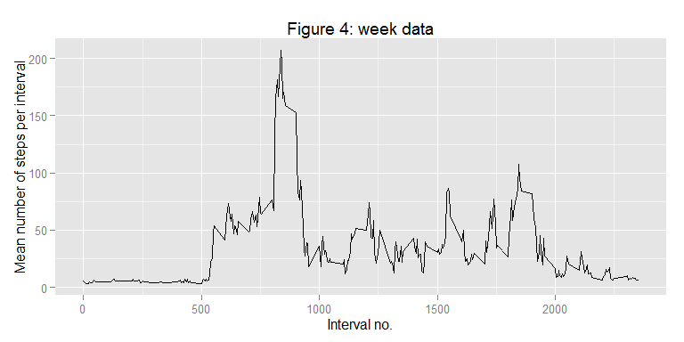

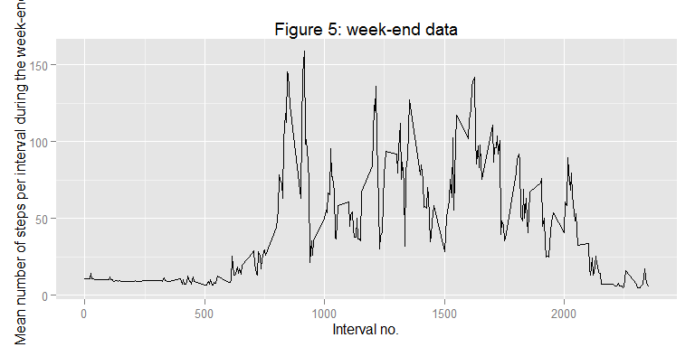

Here we can see week-ends seem to bring along more variety and a later start of the day, as can be expected with a standard life-style of studying/working in the week and leisure activities in the week-end.